# White Wine Quality

Christine_zyu

2019/11/25

# White Wine Quality

这份报告是一份关于白葡萄酒品质与化学成分的分析报告。  
分析的数据集包含4,898个⽩葡萄酒样本，每个样本包含11个化学成分的量化信息和专家对酒的质量的评分。分别为：  
1. fixed acidity 非挥发性酸  
2. volatile acidity 挥发性酸  
3. citric acid 柠檬酸  
4. residual sugar 残留糖分  
5. chlorides 氯化物  
6. free sulfur dioxide 游离二氧化硫  
7. total sulfur dioxide 总二氧化硫  
8. density 密度  
9. pH 酸碱性  
10. sulphates 硫酸盐  
11. alcohol 酒精  
23. quality 质量  
我们希望探讨哪些化学成分会对白葡萄酒的品质有影响。

## 单变量分析

首先，我们希望对各变量有所了解。

### 整体信息

1. 数据集wine的变量信息:

```
## 'data.frame':    4898 obs. of  13 variables:
##  $ X                   : int  1 2 3 4 5 6 7 8 9 10 ...
##  $ fixed.acidity       : num  7 6.3 8.1 7.2 7.2 8.1 6.2 7 6.3 8.1 ...
##  $ volatile.acidity    : num  0.27 0.3 0.28 0.23 0.23 0.28 0.32 0.27 0.3 0.22 ...
##  $ citric.acid         : num  0.36 0.34 0.4 0.32 0.32 0.4 0.16 0.36 0.34 0.43 ...
##  $ residual.sugar      : num  20.7 1.6 6.9 8.5 8.5 6.9 7 20.7 1.6 1.5 ...
##  $ chlorides           : num  0.045 0.049 0.05 0.058 0.058 0.05 0.045 0.045 0.049 0.044 ...
##  $ free.sulfur.dioxide : num  45 14 30 47 47 30 30 45 14 28 ...
##  $ total.sulfur.dioxide: num  170 132 97 186 186 97 136 170 132 129 ...
##  $ density             : num  1.001 0.994 0.995 0.996 0.996 ...
##  $ pH                  : num  3 3.3 3.26 3.19 3.19 3.26 3.18 3 3.3 3.22 ...
##  $ sulphates           : num  0.45 0.49 0.44 0.4 0.4 0.44 0.47 0.45 0.49 0.45 ...
##  $ alcohol             : num  8.8 9.5 10.1 9.9 9.9 10.1 9.6 8.8 9.5 11 ...
##  $ quality             : int  6 6 6 6 6 6 6 6 6 6 ...
```

数据集包含13个变量：变量X为数据编号；11种化学物质含量都是浮点数，为连续变量；白葡萄酒的品质分数为整数，是离散变量。

2. 各变量的统计信息：

```
##        X        fixed.acidity    volatile.acidity  citric.acid
##  Min.   :   1   Min.   : 3.800   Min.   :0.0800   Min.   :0.0000
##  1st Qu.:1225   1st Qu.: 6.300   1st Qu.:0.2100   1st Qu.:0.2700
##  Median :2450   Median : 6.800   Median :0.2600   Median :0.3200
##  Mean   :2450   Mean   : 6.855   Mean   :0.2782   Mean   :0.3342
##  3rd Qu.:3674   3rd Qu.: 7.300   3rd Qu.:0.3200   3rd Qu.:0.3900
##  Max.   :4898   Max.   :14.200   Max.   :1.1000   Max.   :1.6600
##  residual.sugar     chlorides       free.sulfur.dioxide total.sulfur.dioxide
##  Min.   : 0.600   Min.   :0.00900   Min.   :  2.00      Min.   :  9.0
##  1st Qu.: 1.700   1st Qu.:0.03600   1st Qu.: 23.00      1st Qu.:108.0
##  Median : 5.200   Median :0.04300   Median : 34.00      Median :134.0
##  Mean   : 6.391   Mean   :0.04577   Mean   : 35.31      Mean   :138.4
##  3rd Qu.: 9.900   3rd Qu.:0.05000   3rd Qu.: 46.00      3rd Qu.:167.0
##  Max.   :65.800   Max.   :0.34600   Max.   :289.00      Max.   :440.0
##     density             pH          sulphates         alcohol
##  Min.   :0.9871   Min.   :2.720   Min.   :0.2200   Min.   : 8.00
##  1st Qu.:0.9917   1st Qu.:3.090   1st Qu.:0.4100   1st Qu.: 9.50
##  Median :0.9937   Median :3.180   Median :0.4700   Median :10.40
##  Mean   :0.9940   Mean   :3.188   Mean   :0.4898   Mean   :10.51
##  3rd Qu.:0.9961   3rd Qu.:3.280   3rd Qu.:0.5500   3rd Qu.:11.40
##  Max.   :1.0390   Max.   :3.820   Max.   :1.0800   Max.   :14.20
##     quality
##  Min.   :3.000
##  1st Qu.:5.000
##  Median :6.000
##  Mean   :5.878
##  3rd Qu.:6.000
##  Max.   :9.000
```

3. 各变量的分布直方图：

##### Fixed acidity

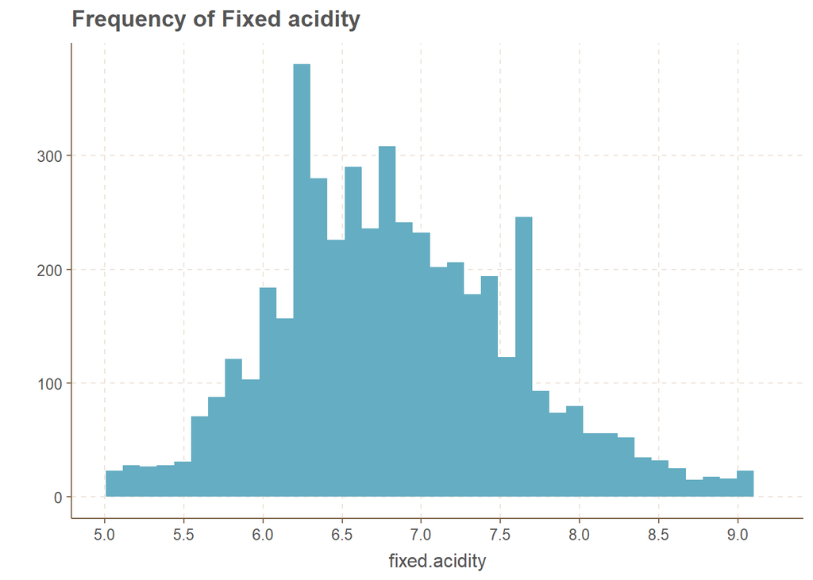

由图可见，非挥发性酸浓度的主要集中在6.25~7.25$g/dm^3$。

#### Volatile acidity

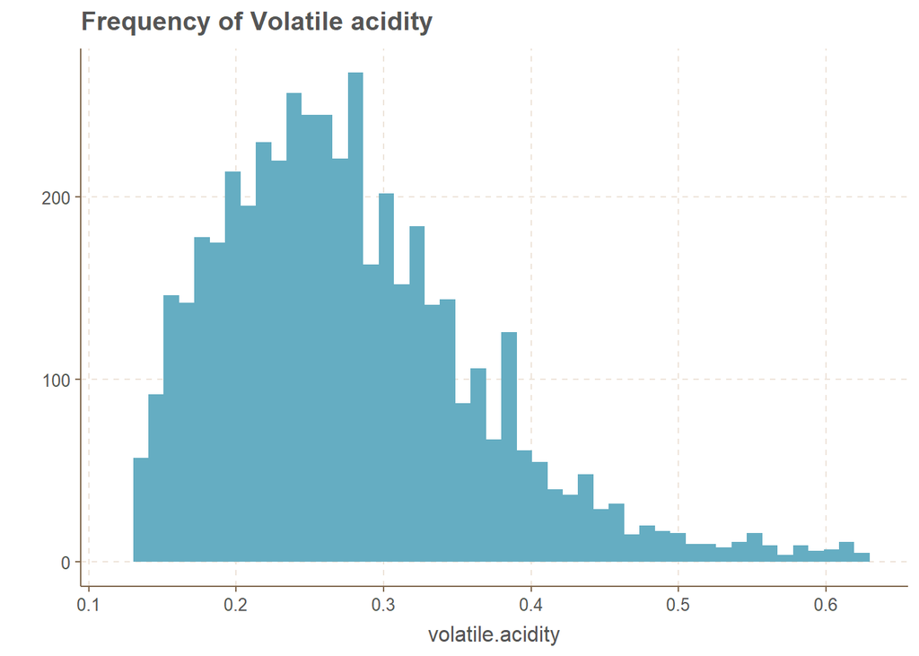

由图可见，挥发性酸浓度的主要集中在0.16~0.3$g/dm^{3}$，挥发性酸浓度超过0.5$g/dm^{3}$的样本非常少。

#### Citric acid

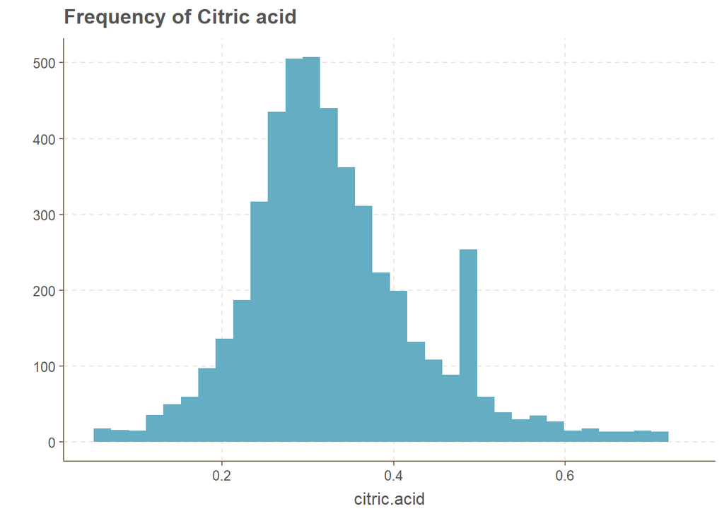

由图可见，柠檬酸浓度的主要集中在0.2~0.4$g/dm^3$。此外，也有相当一部分的白葡萄酒的柠檬酸浓度在0.47-0.49$g/dm^3$之间。只有非挥发性酸浓度超过0.6$g/dm^3$或小于0.1$g/dm^3$的样本非常少。

#### Residual sugar

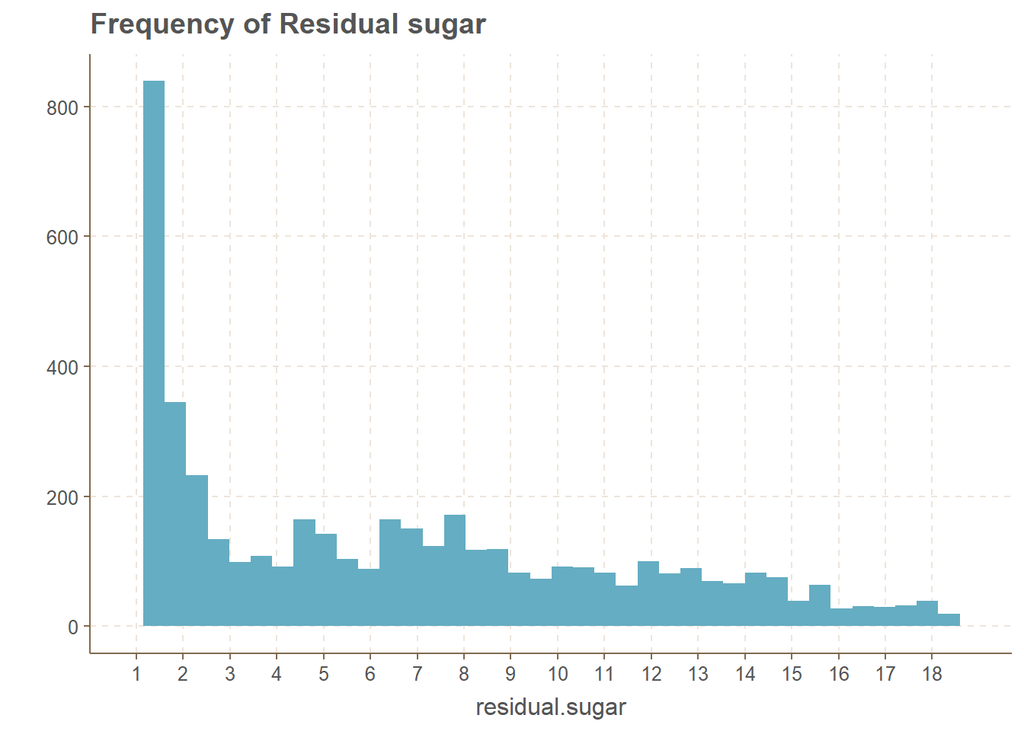

由图可见，残留糖分浓度的主要集中在1.2~2.5$g/dm^3$，呈长尾分布。残留糖分浓度少于1$g/dm^3$几乎没有。  
残留糖分浓度在45$g/dm^3$以上的白葡萄酒被认为是甜葡萄酒。我们也看一下此次样本中残留糖分浓度大于45$g/dm^3$的白葡萄酒。

```
##         X residual.sugar quality
## 2782 2782           65.8       6
```

样本中的甜葡萄酒只有1个，也非常稀少。这瓶葡萄酒的评分为6分，属于中游分数。

#### Chlorides

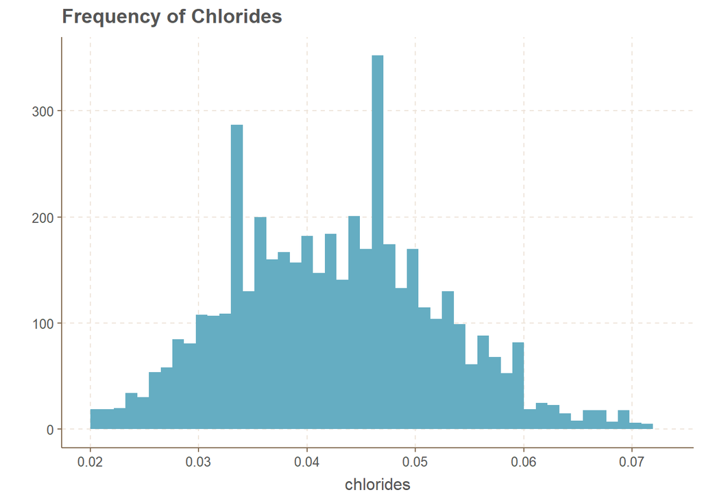

由图可见，氯化物浓度的主要集中在0.036~0.050$g/dm^3$。

#### Free sulfur dioxide

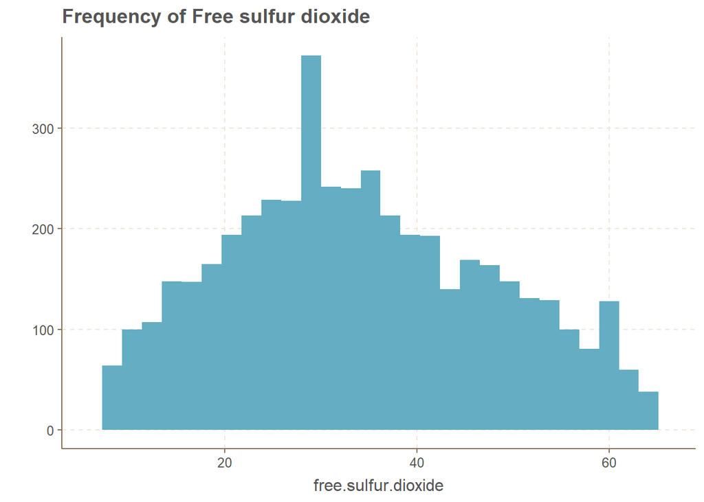

由图可见，游离二氧化硫浓度的主要集中在23~35$mg/dm^3$。此外，也有17.7%的白葡萄酒的游离二氧化硫浓度高于50%，这些葡萄酒的游离二氧化硫浓度过高，会产生明显的二氧化硫的味道和气味，会影响白葡萄酒的品质。

#### Total sulfur dioxide

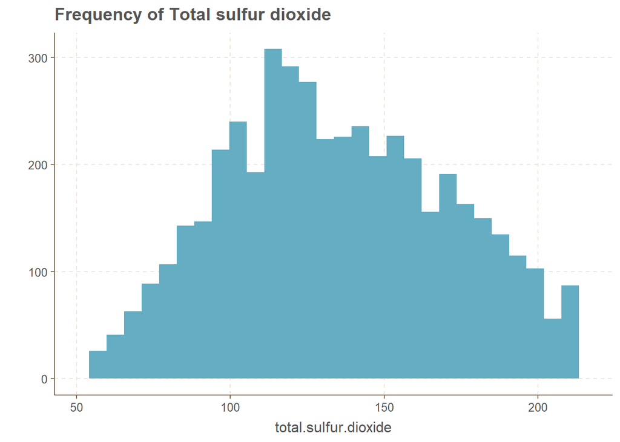

#### Density

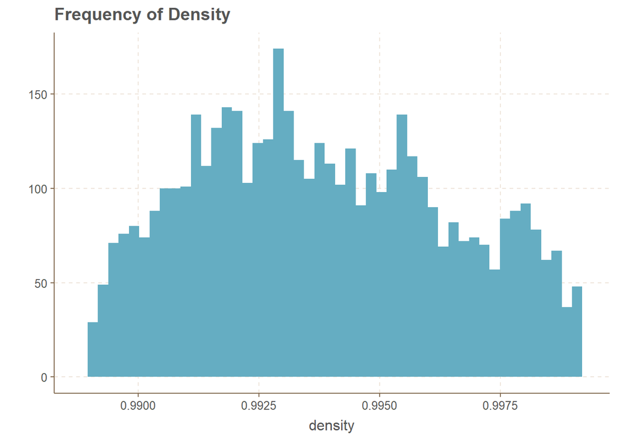

由图可见，密度的主要集中在0.99~1$g/cm^3$，非常接近水的密度，但大部分白葡萄酒都比水的密度稍微小一些。

#### pH

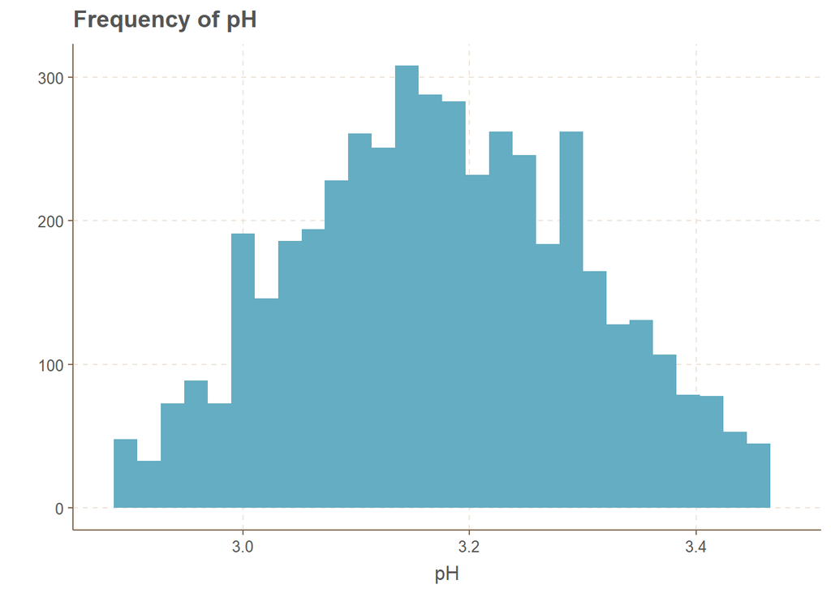

由图可见，pH值的主要集中在3.10-3.25。

#### Sulphates

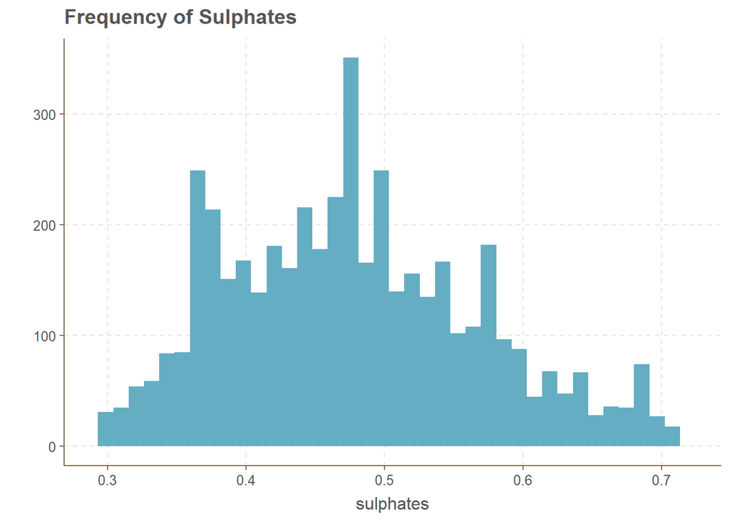

由图可见，硫酸盐浓度的主要集中在0.36-0.54$g/dm^3$。

#### Alcohol

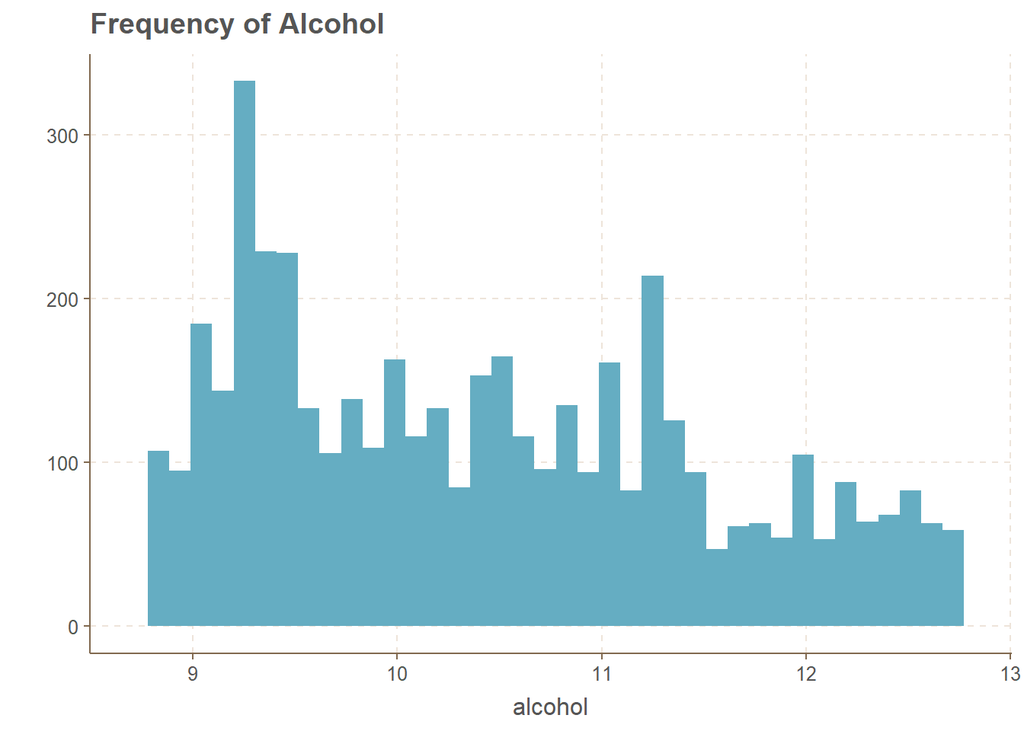

由图可见，酒精浓度在8.8%-12.7%不等，分布相对均匀，其中酒精浓度在9.2-9.4%的白葡萄酒较多。

#### Quality

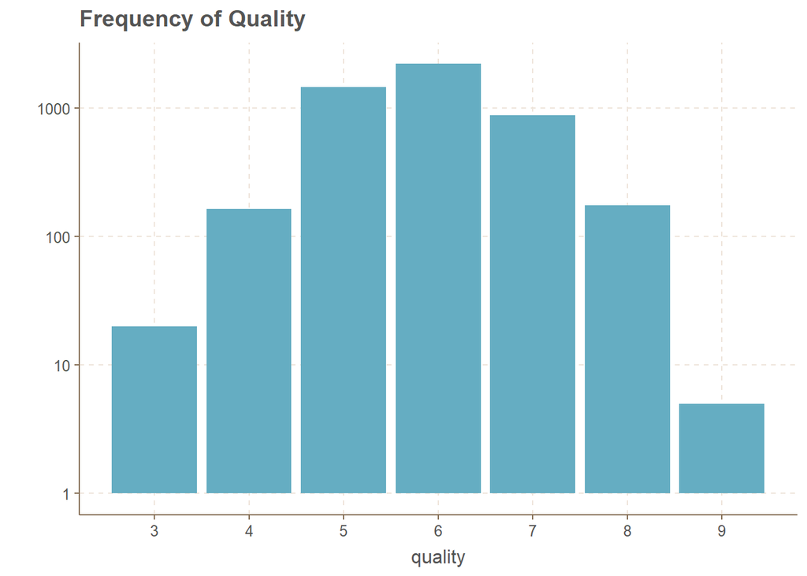

由图可见，专家对样本中的白葡萄酒的品质评分主要集中在5-7分，都有约1000个样本。8-9分的白葡萄酒样本在200个以内，而10分满分的白葡萄酒在这批葡萄酒中未出现。3-4分的样本也非常少。因此，我们可以认为，**8分为优秀，9分为非常优秀，4分及以下的白葡萄酒品质很差**。我们尝试将品质也分为3类，优秀（good）为8-9分，中等（medium）为5-7分，差（bad）为3-4分。

## 双变量分析

为了更好地分析各种化学物质对白葡萄酒品质地影响，我们将穿插进行双变量分析和多变量分析。

#### 散点图矩阵

我们先通过散点图矩阵来快速对各化学物质对白葡萄酒品质的影响有初步了解，便于寻找影响白葡萄酒品质的核心变量。

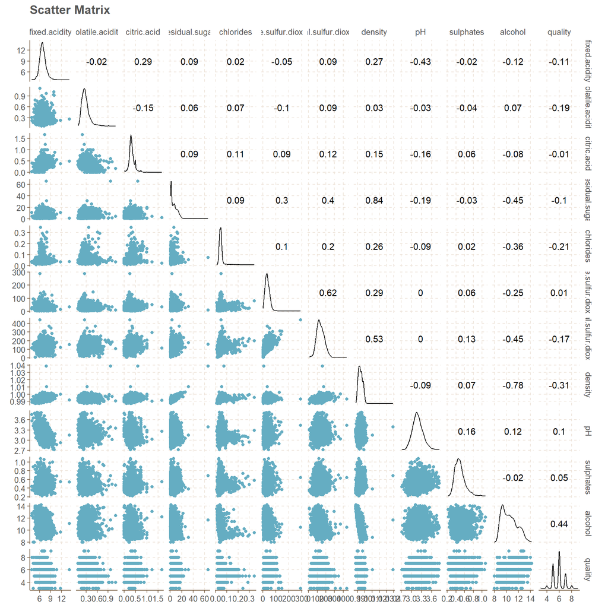

从相关系数来看，**酒精含量、密度与品质有中度相关性，氯化物、挥发酸和非挥发酸有弱相关性**。而在这几个变量中，**只有酒精含量是正相关，其他均为负相关**。 一些葡萄酒爱好者或专家的经验告诉我们，一些化学物质的含量位于某个区间内会带来更好的风味。像葡萄酒的酸，如果酸度太高则过于尖酸，不适合引用，如果过低，葡萄酒则会索然无味。同时，葡萄酒也讲究各种风味的“平衡”，尤其是酒香、酸度和甜度的平衡。  
我们进一步分别探讨各种化学物质对白葡萄酒品质的影响。

#### 酒香（酒精含量）与品质

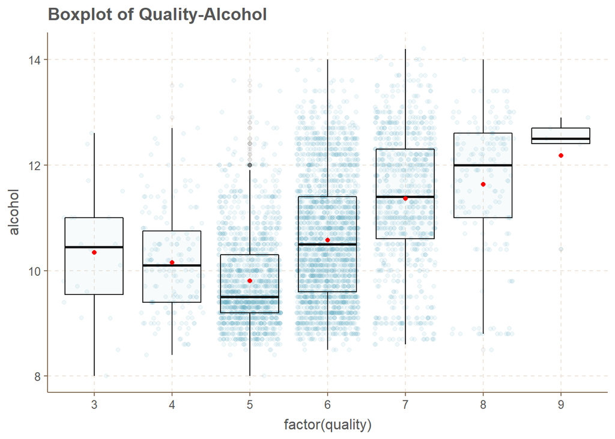

```
##
##  Pearson's product-moment correlation
##
## data:  alcohol and quality
## t = 33.858, df = 4896, p-value < 2.2e-16
## alternative hypothesis: true correlation is not equal to 0
## 95 percent confidence interval:
##  0.4126015 0.4579941
## sample estimates:
##       cor
## 0.4355747
```

从箱型图和相关性测试来看，酒精含量与品质存在中度正相关性。

**结论:**酒精含量与白葡萄酒的品质正相关。人们更偏好与酒香更醇厚的白葡萄酒。

#### 酸度与品质

1. 非挥发酸

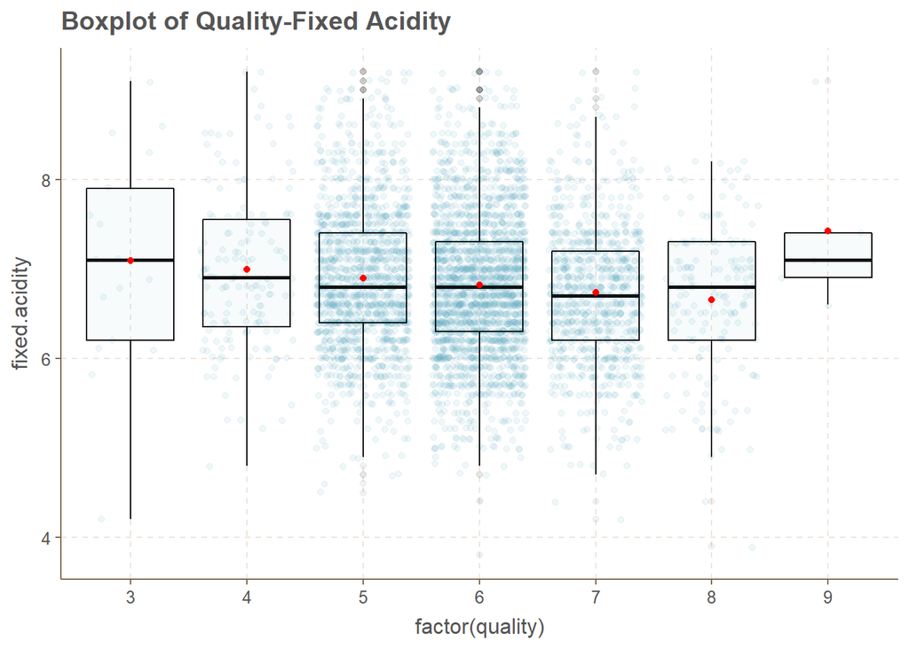

```
##
##  Pearson's product-moment correlation
##
## data:  fixed.acidity and quality
## t = -8.005, df = 4896, p-value = 1.48e-15
## alternative hypothesis: true correlation is not equal to 0
## 95 percent confidence interval:
##  -0.14121974 -0.08592991
## sample estimates:
##        cor
## -0.1136628
```

从散点图来看，非挥发酸对品质影响并不明显。从相关性测试来看，非挥发酸含量与白葡萄酒品质有负向弱相关性。

**结论:**非挥发酸含量对白葡萄酒的品质有负向弱相关性。相对来说，人们更偏好非挥发性酸更少的白葡萄酒。

2. 挥发酸

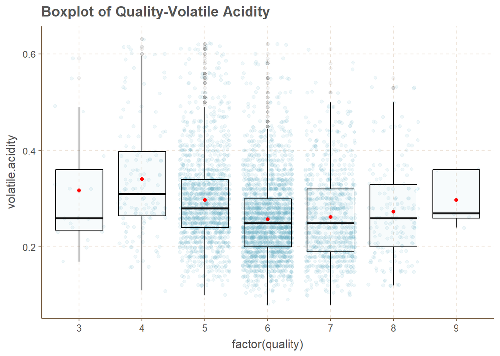

```
##
##  Pearson's product-moment correlation
##
## data:  volatile.acidity and quality
## t = -13.891, df = 4896, p-value < 2.2e-16
## alternative hypothesis: true correlation is not equal to 0
## 95 percent confidence interval:
##  -0.2215214 -0.1676307
## sample estimates:
##       cor
## -0.194723
```

从箱型图来看，挥发酸含量与品质存在一定的负相关性。相关性测试显示两者间有负向弱相关性。

**结论:**挥发酸含量与品质存在负相关性。白葡萄酒的挥发酸会给人们带来不佳的体验。

3. 柠檬酸

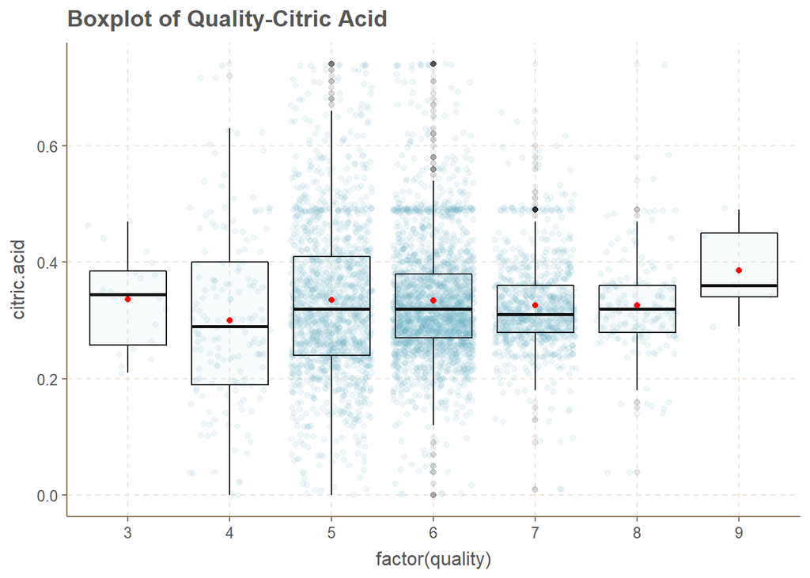

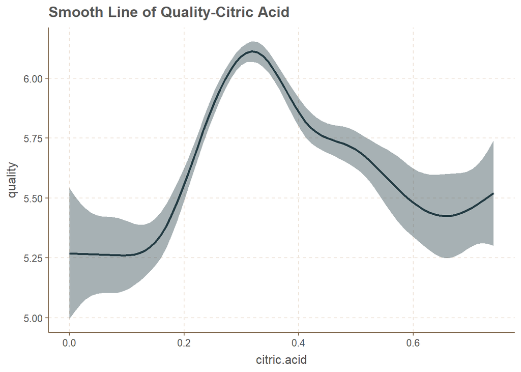

```
##
##  Pearson's product-moment correlation
##
## data:  citric.acid and quality
## t = -0.6444, df = 4896, p-value = 0.5193
## alternative hypothesis: true correlation is not equal to 0
## 95 percent confidence interval:
##  -0.03720595  0.01880221
## sample estimates:
##          cor
## -0.009209091
```

从箱型图和相关性测试来看，柠檬酸含量与品质不存在明显的线性相关性。但从拟合线来看，柠檬酸含量在某个区间内的白葡萄酒品质似乎更佳。

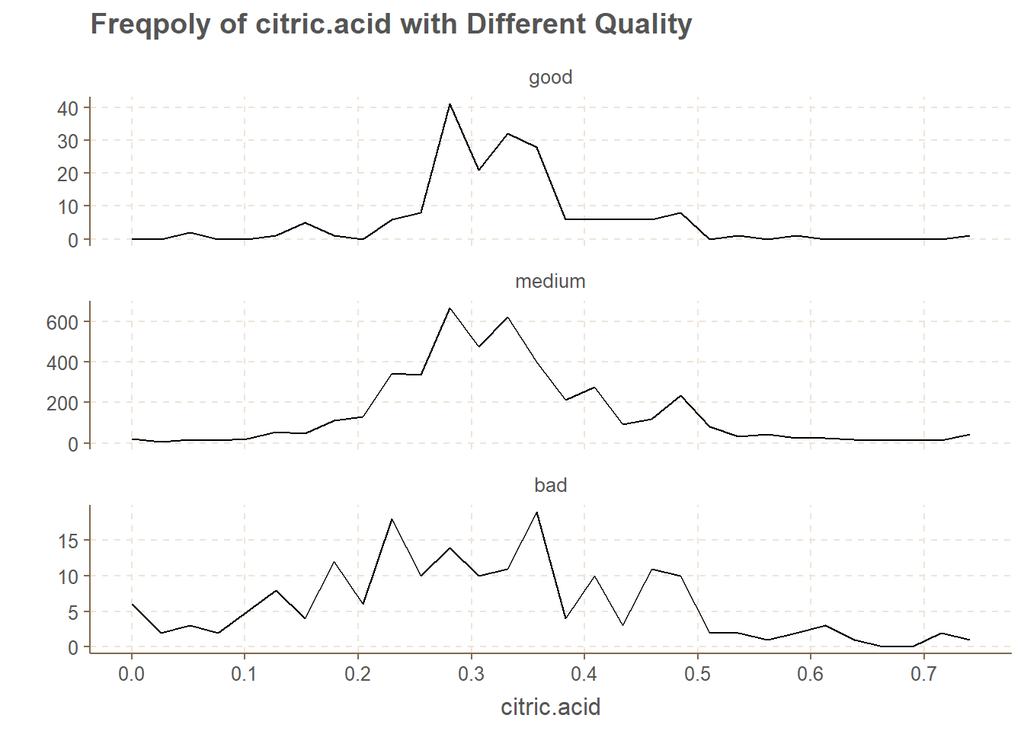

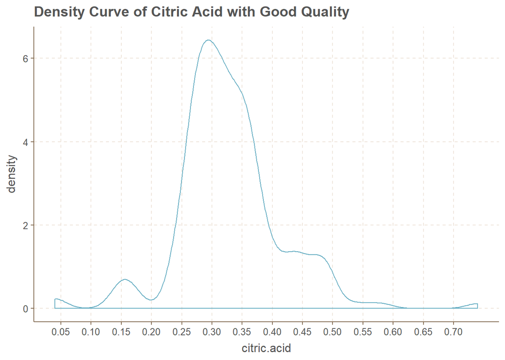

从频率多边形和优秀品质酒的密度曲线来看，高质量的白葡萄酒的柠檬酸含量集中在0.25-0.37$g/dm^3$，在区间外的酒的平均品质相对不佳。我们猜测0.27-0.37$g/dm^3$为柠檬酸的适宜含量区间。

```
##
##  Pearson's product-moment correlation
##
## data:  cacid_good[, 1] and wine$quality
## t = 16.204, df = 4896, p-value < 2.2e-16
## alternative hypothesis: true correlation is not equal to 0
## 95 percent confidence interval:
##  0.1988638 0.2520277
## sample estimates:
##       cor
## 0.2256138
```

经过相关性测试，柠檬酸含量在适宜区间（0.27-0.37$g/dm^3$）与品质有正向弱相关性。

**结论:**柠檬酸含量会影响白葡萄酒的品质。柠檬酸含量在适宜区间（0.27-0.37$g/dm^3$）附近的白葡萄酒品质会更佳。这也与我们对柠檬酸的认识相一致。适量的柠檬酸可为葡萄酒增添风味，但柠檬酸含量过高，葡萄酒就会太酸而难以入口。

#### 甜度（残留糖分）与品质

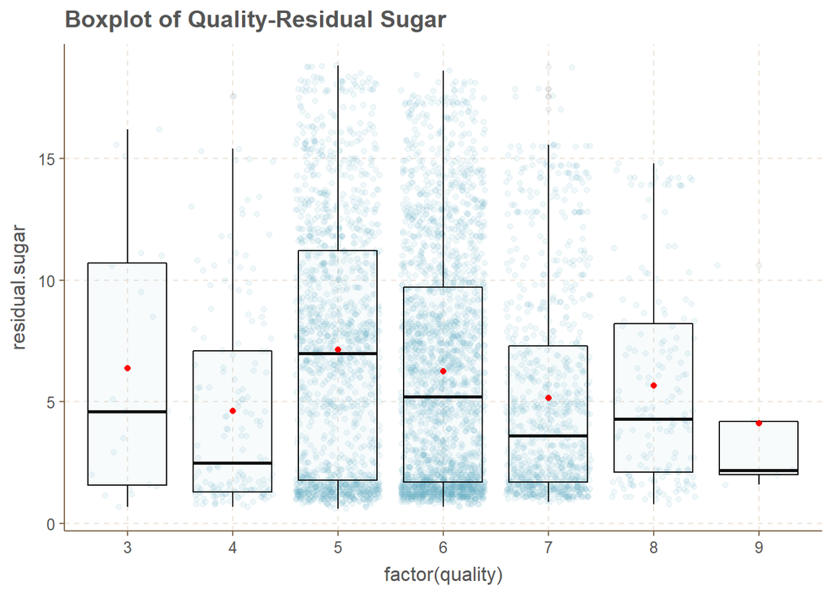

```
##
##  Pearson's product-moment correlation
##
## data:  residual.sugar and quality
## t = -6.8603, df = 4896, p-value = 7.724e-12
## alternative hypothesis: true correlation is not equal to 0
## 95 percent confidence interval:
##  -0.12524103 -0.06976101
## sample estimates:
##         cor
## -0.09757683
```

从箱型图来看，残留糖分含量与品质相关性不是很明显。相关性测试显示两者间有负向弱相关性。

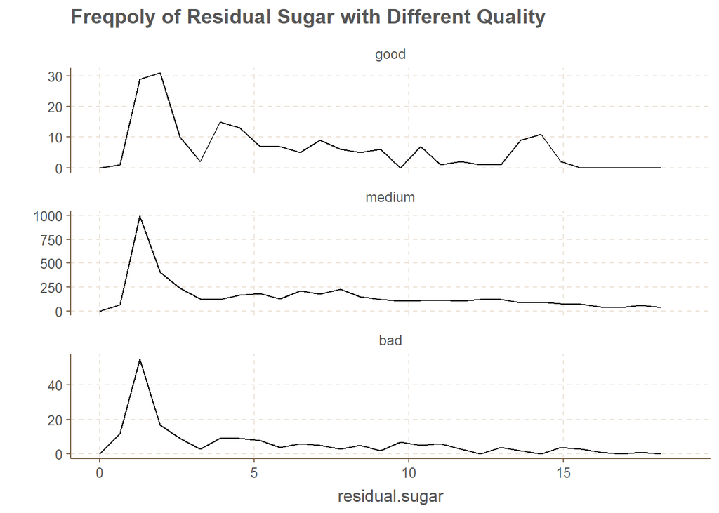

但当我们将葡萄酒的品质分层来看，可以高品质的葡萄酒中也有相当一部分的残留糖分含量比较高，其占比甚至甚至比中等和低品质的葡萄酒更高。  
从现有结论来看，并不能说明残留糖分高或低的葡萄酒品质更好。

**结论:**残留糖分含量与品质没有明显的相关关系。

#### 含硫物质（防腐剂）与品质

1. 游离二氧化硫与品质

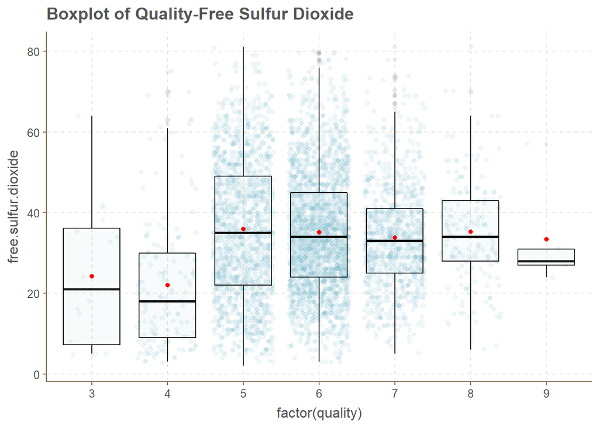

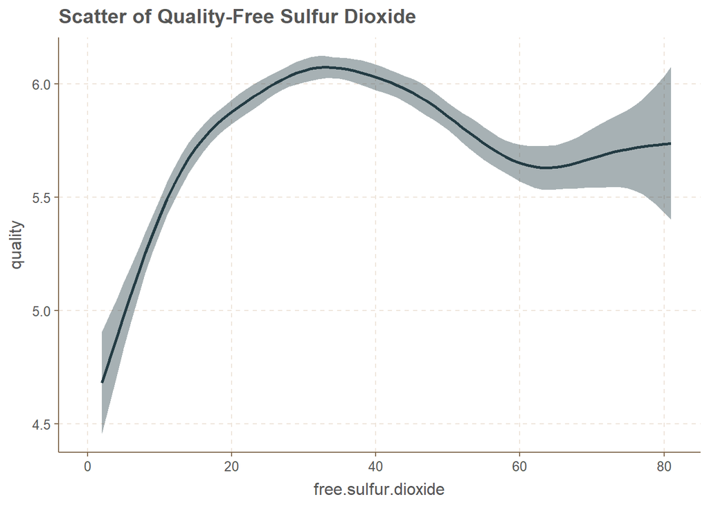

```
##
##  Pearson's product-moment correlation
##
## data:  free.sulfur.dioxide and quality
## t = 0.57085, df = 4896, p-value = 0.5681
## alternative hypothesis: true correlation is not equal to 0
## 95 percent confidence interval:
##  -0.01985292  0.03615626
## sample estimates:
##         cor
## 0.008158067
```

从箱型图来看，高分样本的游离二氧化碳含量比较集中。从拟合线来看，随着游离二氧化硫含量增加，葡萄酒的评分先上升后下降。  
我们希望分析游离二氧化硫含量在什么区间内比较合适。

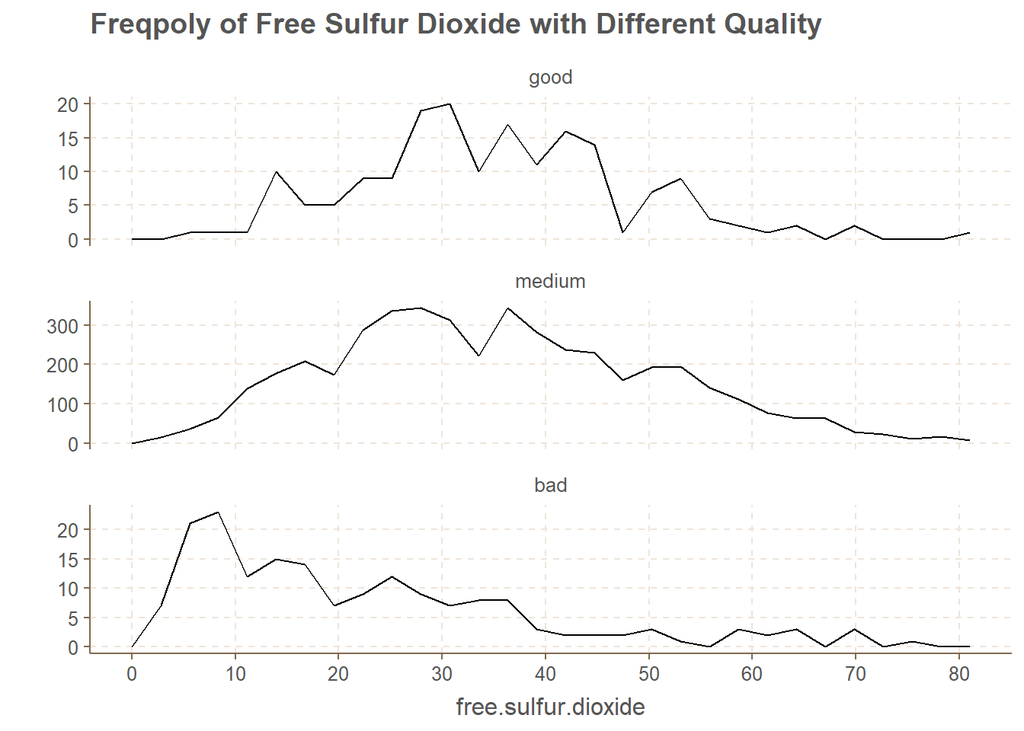

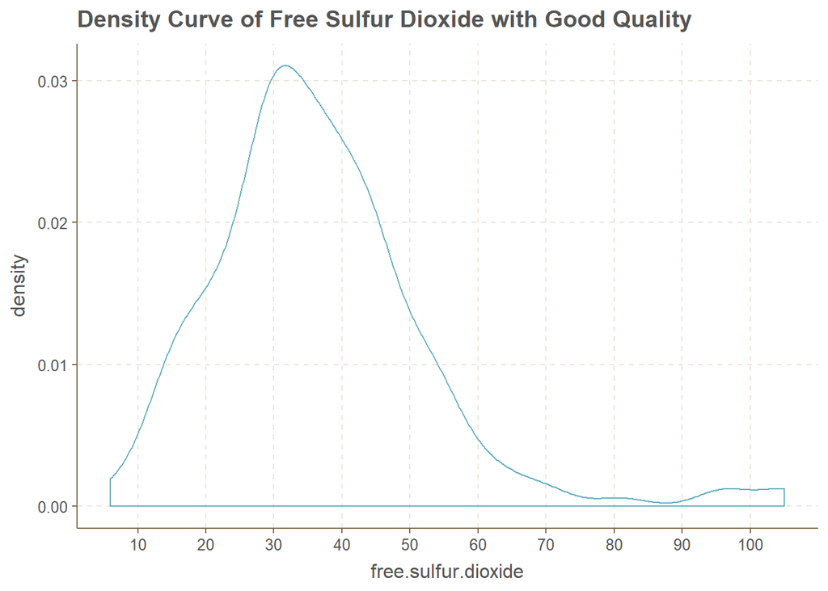

从频率多边形和优秀品质酒的密度曲线来看，游离二氧化碳的适宜区间会比较宽，初步假设20-50$mg/dm^3$为游离二氧化硫的适宜含量区间。

```
##
##  Pearson's product-moment correlation
##
## data:  fsuld_good[, 1] and wine$quality
## t = 13.17, df = 4896, p-value < 2.2e-16
## alternative hypothesis: true correlation is not equal to 0
## 95 percent confidence interval:
##  0.1577799 0.2118779
## sample estimates:
##      cor
## 0.184969
```

经过相关性测试，游离二氧化硫含量在适宜区间（20-50$mg/dm^3$）与品质有正向弱相关性。

2. 总二氧化硫与品质

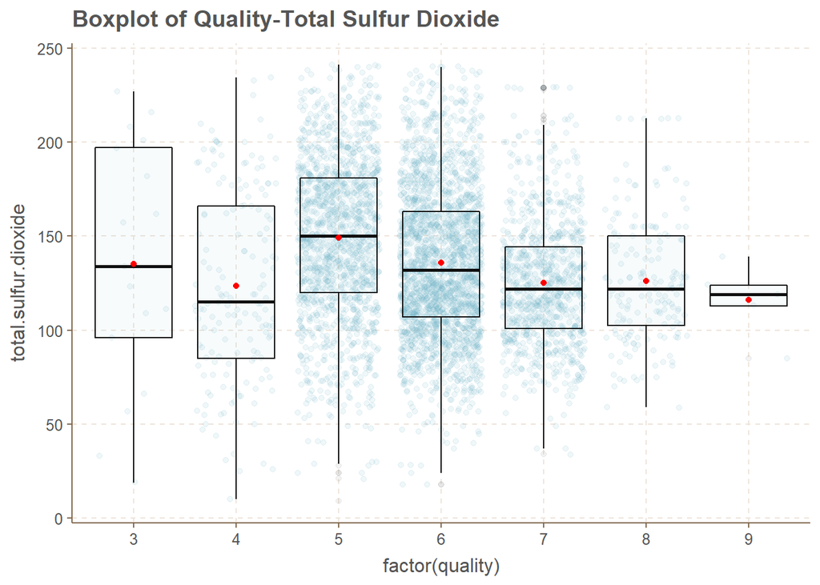

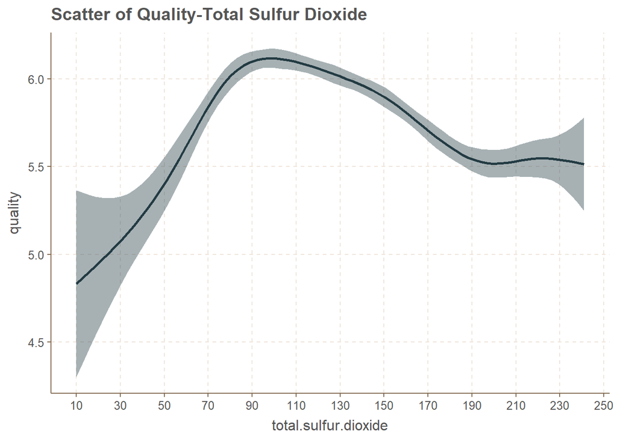

```
##
##  Pearson's product-moment correlation
##
## data:  total.sulfur.dioxide and quality
## t = -12.418, df = 4896, p-value < 2.2e-16
## alternative hypothesis: true correlation is not equal to 0
## 95 percent confidence interval:
##  -0.2017563 -0.1474524
## sample estimates:
##        cor
## -0.1747372
```

与游离二氧化硫相似，随着总二氧化硫含量增加，葡萄酒的评分先上升后下降。而从相关测试来看，总二氧化碳与品质呈负向弱相关性。我们猜测，可能总二氧化硫对白葡萄酒的风味影响更大。  
我们进一步分析总二氧化硫含量在什么区间内比较合适。

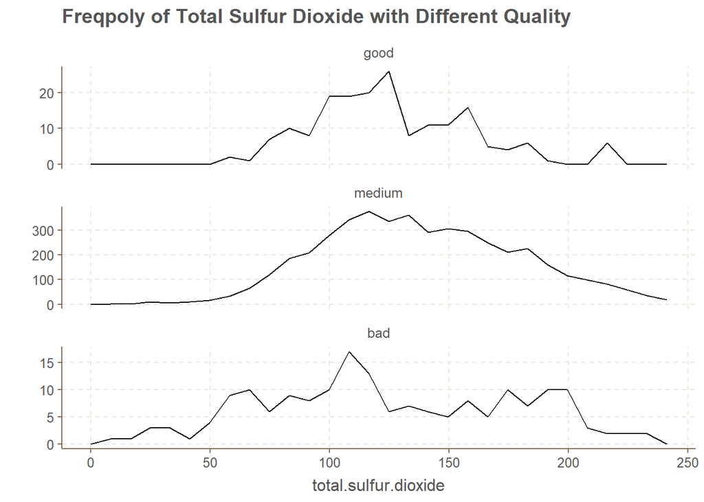

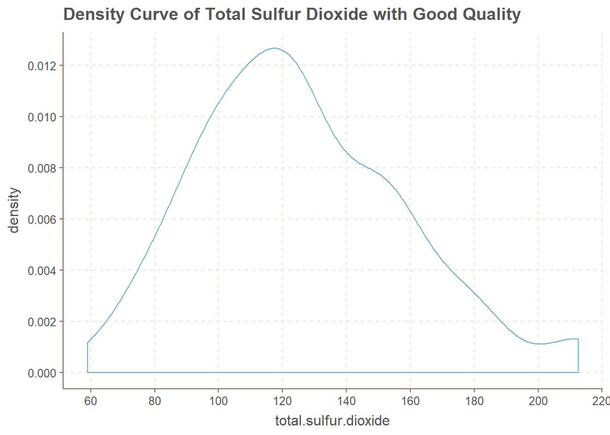

从频率多边形和优秀品质酒的密度曲线来看，总二氧化碳的适宜区间会比较宽，初步假设80-160$mg/dm^3$为总二氧化硫的适宜含量区间。

```
##
##  Pearson's product-moment correlation
##
## data:  tsuld_good[, 1] and wine$quality
## t = 15.781, df = 4896, p-value < 2.2e-16
## alternative hypothesis: true correlation is not equal to 0
## 95 percent confidence interval:
##  0.1931955 0.2464991
## sample estimates:
##       cor
## 0.2200115
```

**结论:**总二氧化硫含量会影响白葡萄酒的品质。总二氧化硫含量在适宜区间（80-160$mg/dm^3$）附近的白葡萄酒品质会更佳。

3. 硫酸盐与品质

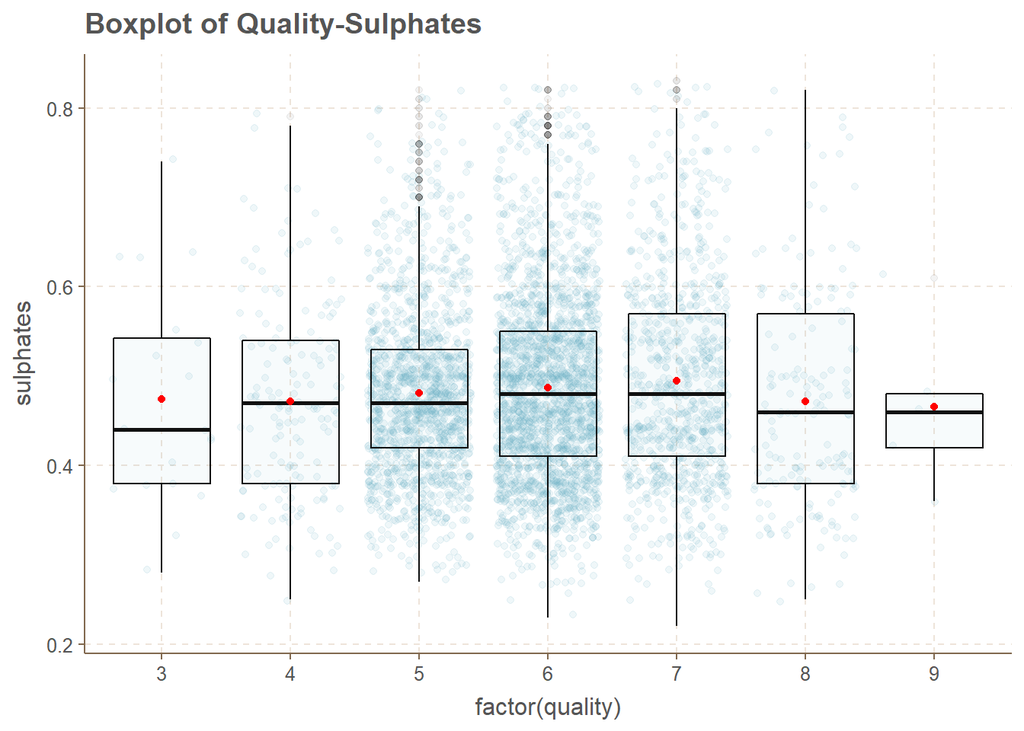

```
##
##  Pearson's product-moment correlation
##
## data:  sulphates and quality
## t = 3.7613, df = 4896, p-value = 0.000171
## alternative hypothesis: true correlation is not equal to 0
## 95 percent confidence interval:
##  0.02571007 0.08156172
## sample estimates:
##        cor
## 0.05367788
```

从散点图和相关性测试来看，硫酸盐含量与品质不存在明显的线性相关性。

**结论:**硫酸盐含量对白葡萄酒的品质没有明显的影响。硫酸盐在液体中比较稳定，且没有明显的味道，因此对白葡萄酒的品质印象不大。